# 서울 공공자전거 시간당 대여량 예측

## 전체 분석 흐름

### PART 1 - 문제 정의와 탐색적 데이터 분석(EDA)

**1. 예측문제 정의**시간대, 날씨로  
시간당 대여량 추정

**2. 탐색적 분석**분포, 시간 패턴  
기온, 강수와의 관계

무엇을 예측하며, 어떤 단서가 있는가?

### PART 2 - 전처리

**3. 데이터 전처리**운영 기록, 입력 선택  
학습/평가로 분리

모델이 사용할 표와 확인할 기간 확정

### PART 3 - 모델링과 결과 해석

**4. 모델링**중앙값, 회귀, 나무  
랜덤 포레스트 학습

**5. 평가**같은 평가 자료로  
모델별 오차 비교

**6. 인사이트 도출**큰 오차 사례 확인  
활용 방안과 한계

얼마나 틀리며, 어디까지 활용할 수 있는가?

### Part 1 - 무엇을 살펴보나요?

- CSV 파일 불러오기
- 처음 다섯 행과 행, 열의 수 확인
- 열 이름을 짧게 바꾸기
- 날짜를 날짜형으로 바꾸기
- 기록의 시작일과 종료일 확인
- 운영 여부별 기록 수 확인
- 운영 기록을 학습 자료와 평가 자료로 나누기
- 학습 자료만 탐색용으로 복사
- 대여량의 기술통계, 평균과 중앙값 확인
- 기온과 대여량의 상관계수 확인
- 습도와 대여량의 상관계수 확인
- 15℃ 이상 20℃ 미만 기록의 시간대별 개수와 평균 비교
- 시간대별 평균 대여량 계산
- 평균 대여량이 가장 높은 시각 찾기
- 강수 여부별 기록 수와 평균 대여량 비교
- 습도 구간별 기록 수와 평균 대여량 비교
- 관찰한 내용과 입력 후보 및 모델 비교 계획 연결

### Part 2 - 데이터를 어떻게 준비하나요?

- 열별 결측값 개수 확인
- 중복 행 개수 확인
- 시각의 최솟값과 최댓값 확인
- 습도의 최솟값과 최댓값 확인
- 대여 건수의 최솟값 확인
- 강수량의 최솟값 확인
- 시간대, 기온, 습도, 강수량을 입력으로 선택
- 실제 대여 건수를 정답으로 선택
- 입력 표와 정답 열의 앞부분 확인
- 학습과 예측, 평가에서 입력과 정답의 역할 구분

### Part 3 - 어떻게 예측하고 판단하나요?

- 학습 대여량의 중앙값 계산
- 중앙값으로 평가 자료를 예측하고 평균 오차 계산
- 기온 하나로 선형 회귀 학습
- 기울기와 절편 확인
- 기온 모델의 평가 예측과 평균 오차 계산
- 기온에 시간대를 추가하여 평가 평균 오차 비교
- 강수량을 추가하여 평가 평균 오차 비교
- 습도를 추가하여 평가 평균 오차 비교
- 입력을 추가한 네 선형 회귀의 오차를 표로 비교
- 의사결정나무를 학습하고 평가 평균 오차 계산
- 랜덤 포레스트를 학습하고 평가 평균 오차 계산
- 방법별 평가 평균 오차를 표로 비교
- 실제값, 예측값, 절대 오차를 표로 확인
- 오차가 큰 다섯 기록 확인
- 시간대별 평균 오차를 표로 확인
- 새로운 시간대와 날씨 조건을 입력해 대여량 예측

# 서울 공공자전거 시간당 대여량 예측

## Part 1 - 문제 정의와 탐색적 데이터 분석(EDA)

### 1-1. 무엇을 예측할까요?

기온만 사용했을 때와 시간대, 강수량, 습도를 차례로 추가했을 때의 예측 오차를 비교합니다.

| 구분 | 내용 |
| --- | --- |
| 정답 | 실제 대여 건수 |
| 대상 | 자전거를 운영한 시간의 기록 |
| 입력 후보 | 기온, 시간대, 강수량, 습도 |
| 평가 | 실제값과 예측값의 평균적인 차이 |

분석은 **학습 자료에서 특징 관찰 → 입력 후보와 모델 결정 → 코드에 반영 → 평가 결과 확인** 순서로 진행합니다. 모든 모델과 입력 조합을 평가 전에 정하고, 평가 결과를 보고 설정을 반복해서 바꾸지 않습니다.

### 1-2. 도구와 데이터 불러오기

`pandas`는 표를 다룹니다. 세 모델은 입력과 정답의 관계를 학습하고, `mean_absolute_error`는 예측 오차를 계산합니다.

Python - 1

```
import pandas as pd
import matplotlib.pyplot as plt
from sklearn.linear_model import LinearRegression
from sklearn.tree import DecisionTreeRegressor
from sklearn.ensemble import RandomForestRegressor
from sklearn.metrics import mean_absolute_error

plt.rcParams["font.family"] = "Malgun Gothic"
plt.rcParams["axes.unicode_minus"] = False
```

**코드 사용법과 결과 읽기**

- `import pandas as pd`는 pandas를 불러와 `pd`라는 짧은 이름으로 사용합니다.
- `matplotlib.pyplot`은 그래프를 그리는 도구이고 `plt`라는 이름으로 사용합니다. `rcParams`는 한글 글꼴과 음수 기호의 표시 설정입니다.
- `from 도구 import 이름`은 필요한 모델이나 함수를 가져옵니다. 이 단계에서 모델이 학습되는 것은 아닙니다.
- `LinearRegression`은 선형 회귀, `DecisionTreeRegressor`는 회귀나무, `RandomForestRegressor`는 여러 회귀나무의 예측을 평균하는 모델입니다.
- `mean_absolute_error(실제값, 예측값)`은 평균 절대 오차를 숫자 하나로 반환합니다.

Python - 2

```
raw = pd.read_csv("SeoulBikeData.csv", encoding="latin1")
display(raw.head())
print("행과 열의 수:", raw.shape)
```

실제 실행 결과

|  | Date | Rented Bike Count | Hour | Temperature(°C) | Humidity(%) | Wind speed (m/s) | Visibility (10m) | Dew point temperature(°C) | Solar Radiation (MJ/m2) | Rainfall(mm) | Snowfall (cm) | Seasons | Holiday | Functioning Day |
| --- | --- | --- | --- | --- | --- | --- | --- | --- | --- | --- | --- | --- | --- | --- |
| 0 | 01/12/2017 | 254 | 0 | -5.2 | 37 | 2.2 | 2000 | -17.6 | 0.0 | 0.0 | 0.0 | Winter | No Holiday | Yes |
| 1 | 01/12/2017 | 204 | 1 | -5.5 | 38 | 0.8 | 2000 | -17.6 | 0.0 | 0.0 | 0.0 | Winter | No Holiday | Yes |
| 2 | 01/12/2017 | 173 | 2 | -6.0 | 39 | 1.0 | 2000 | -17.7 | 0.0 | 0.0 | 0.0 | Winter | No Holiday | Yes |
| 3 | 01/12/2017 | 107 | 3 | -6.2 | 40 | 0.9 | 2000 | -17.6 | 0.0 | 0.0 | 0.0 | Winter | No Holiday | Yes |
| 4 | 01/12/2017 | 78 | 4 | -6.0 | 36 | 2.3 | 2000 | -18.6 | 0.0 | 0.0 | 0.0 | Winter | No Holiday | Yes |

```
행과 열의 수: (8760, 14)
```

**코드 사용법과 반환값**

- `pd.read_csv("파일 이름", encoding="글자 방식")`은 CSV 파일을 읽어 **데이터프레임, 즉 표**를 반환합니다. 그 결과를 `raw`에 저장합니다.
- `encoding="latin1"`은 이 CSV의 온도 기호가 포함된 열 이름을 읽기 위한 설정입니다.
- `raw.head()`는 앞의 다섯 행을 표로 반환합니다. `raw.head(3)`처럼 행 수를 지정할 수도 있습니다.
- `display(표)`는 표를 화면에 표시합니다. `raw.shape`는 `(행 수, 열 수)`이고, 함수가 아니므로 뒤에 `()`를 붙이지 않습니다.
- `print(값)`은 글자나 숫자를 출력합니다. 여기서는 `"행과 열의 수:"`라는 문장과 `raw.shape`를 함께 표시합니다.

열 이름을 짧게 바꾸면 아래 코드에서 입력을 선택하기 편합니다. 값이나 행 순서는 바꾸지 않습니다.

Python - 3

```
bike = raw.copy()
bike.columns = [
    "date", "rented_count", "hour", "temperature", "humidity",
    "wind_speed", "visibility", "dew_point", "solar_radiation",
    "rainfall", "snowfall", "season", "holiday", "functioning_day"
]
display(bike.head())
```

실제 실행 결과

|  | date | rented_count | hour | temperature | humidity | wind_speed | visibility | dew_point | solar_radiation | rainfall | snowfall | season | holiday | functioning_day |
| --- | --- | --- | --- | --- | --- | --- | --- | --- | --- | --- | --- | --- | --- | --- |
| 0 | 01/12/2017 | 254 | 0 | -5.2 | 37 | 2.2 | 2000 | -17.6 | 0.0 | 0.0 | 0.0 | Winter | No Holiday | Yes |
| 1 | 01/12/2017 | 204 | 1 | -5.5 | 38 | 0.8 | 2000 | -17.6 | 0.0 | 0.0 | 0.0 | Winter | No Holiday | Yes |
| 2 | 01/12/2017 | 173 | 2 | -6.0 | 39 | 1.0 | 2000 | -17.7 | 0.0 | 0.0 | 0.0 | Winter | No Holiday | Yes |
| 3 | 01/12/2017 | 107 | 3 | -6.2 | 40 | 0.9 | 2000 | -17.6 | 0.0 | 0.0 | 0.0 | Winter | No Holiday | Yes |
| 4 | 01/12/2017 | 78 | 4 | -6.0 | 36 | 2.3 | 2000 | -18.6 | 0.0 | 0.0 | 0.0 | Winter | No Holiday | Yes |

**코드 사용법과 반환값**

- `raw.copy()`는 원본 표의 복사본을 반환합니다. 복사본을 `bike`에 저장해 열 이름을 바꿉니다.
- `bike.columns`는 열 이름 모음입니다. `= [...]`로 새 이름들을 대입합니다. 이름의 개수와 순서는 원래 열과 맞춰야 합니다.
- 대괄호 안의 쉼표로 구분된 이름들은 **리스트**입니다. 실제 데이터 값과 행의 순서는 바뀌지 않습니다.
- `bike.head()`로 바뀐 이름을 확인하고 `display()`로 표시합니다.

| 열 | 뜻 |
| --- | --- |
| `date` | 날짜 |
| `rented_count` | 한 시간의 대여 건수 |
| `hour` | 시각, 0~23시 |
| `temperature` | 기온, ℃ |
| `humidity` | 습도, % |
| `rainfall` | 강수량, mm |
| `functioning_day` | 운영 여부, Yes 또는 No |

글자로 읽힌 날짜를 날짜형으로 바꾸고 기록 기간과 운영 여부를 확인합니다.

Python - 4

```
bike["date"] = pd.to_datetime(bike["date"], format="%d/%m/%Y")
print("처음 날짜:", bike["date"].min())
print("마지막 날짜:", bike["date"].max())
display(bike["functioning_day"].value_counts())
```

실제 실행 결과

```
처음 날짜: 2017-12-01 00:00:00
마지막 날짜: 2018-11-30 00:00:00
```

```
functioning_day
Yes    8465
No      295
Name: count, dtype: int64
```

**코드 사용법과 반환값**

- `pd.to_datetime(날짜열, format="형식")`은 날짜 글자를 날짜 자료형으로 바꾼 열을 반환합니다. 결과를 `bike["date"]`에 다시 저장합니다.
- `%d/%m/%Y`는 일/월/네 자리 연도 순서입니다. 예를 들어 `01/12/2017`은 2017년 12월 1일입니다.
- 날짜 열의 `.min()`은 가장 이른 날짜, `.max()`는 가장 늦은 날짜 하나를 반환합니다.
- `.value_counts()`는 값별 개수가 담긴 열을 반환합니다. 여기서는 운영 여부 `Yes`와 `No`가 각각 몇 행인지 셉니다.

### 1-3. 관계를 찾을 자료와 평가할 자료 구분하기

운영하지 않은 시간과 운영했지만 이용량이 적은 시간은 구분해야 합니다. 운영한 시간의 수요를 예측하므로 `Yes`인 기록을 선택합니다.

앞선 기간을 학습 자료, 뒤 기간을 평가 자료로 나눕니다. EDA에서는 학습 자료의 복사본인 `explore`만 살펴봅니다. 평가 자료의 정답을 보며 입력을 고르면 이미 본 답에 맞춘 선택이 될 수 있기 때문입니다. 학습에 쓰지 않은 뒤 기간에서 오차를 확인해야 새로운 기록에도 적용되는지 판단할 수 있습니다.

Python - 5

```
operating = bike[bike["functioning_day"] == "Yes"].copy()
train = operating[operating["date"] < "2018-09-01"].copy()
test = operating[operating["date"] >= "2018-09-01"].copy()
explore = train.copy()
print("학습 기록 수:", len(train))
print("평가 기록 수:", len(test))
```

실제 실행 결과

```
학습 기록 수: 6528
평가 기록 수: 1937
```

**코드 사용법과 결과 읽기**

- `== "Yes"`는 각 행의 운영 여부를 참 또는 거짓으로 표시하는 조건입니다.
- `표[조건]`은 조건이 참인 행만 담은 데이터프레임을 반환합니다. `copy()`는 그 표의 복사본을 만듭니다.
- `<`는 기준 날짜 이전, `>=`는 기준 날짜와 같거나 이후입니다. 같은 날짜의 기록이 두 묶음에 섞이지 않습니다.
- `len(표)`는 행 수를 반환합니다. 학습은 6,528행, 평가는 1,937행입니다.
- `explore`는 학습 표의 복사본입니다. 탐색용 열을 추가해도 원래 학습 표는 바뀌지 않습니다.

### 1-4. 대여량을 대표값 하나로 설명할 수 있을까요?

평균과 중앙값, 최댓값을 함께 읽습니다. 큰 값이 평균에 영향을 줄 수 있으므로 한 숫자만 보고 모든 시간이 비슷하다고 판단하지 않습니다.

Python - 6

```
display(explore["rented_count"].describe())
print("평균:", explore["rented_count"].mean())
print("중앙값:", explore["rented_count"].median())
```

실제 실행 결과

```
count    6528.000000
mean      671.310049
std       638.217318
min         2.000000
25%       189.000000
50%       424.000000
75%       997.250000
max      3556.000000
Name: rented_count, dtype: float64
```

```
평균: 671.3100490196078
중앙값: 424.0
```

**코드 사용법과 반환값**

- `explore["rented_count"]`는 대여 건수 열 하나를 **시리즈** 형태로 고릅니다.
- `.describe()`는 개수, 평균, 표준편차, 최솟값, 사분위수, 최댓값이 담긴 요약 열을 반환합니다.
- `.mean()`은 평균 숫자 하나, `.median()`은 중앙값 숫자 하나를 반환합니다. 중앙값은 크기순 가운데 값이며 개수가 짝수이면 가운데 두 값의 평균입니다.
- `display()`는 요약 통계를, `print()`는 평균과 중앙값을 표시합니다.

대여량의 분포를 히스토그램으로 확인합니다. 낮은 대여량이 모이는 구간과 오른쪽으로 길게 이어지는 큰 값을 함께 읽습니다.

Python

```
explore["rented_count"].plot(kind="hist", bins=20)
plt.xlabel("한 시간 대여 건수")
plt.ylabel("시간 기록 수")
plt.title("대여량은 어느 구간에 많이 모여 있을까요?")
plt.show()
```

실제 실행 결과

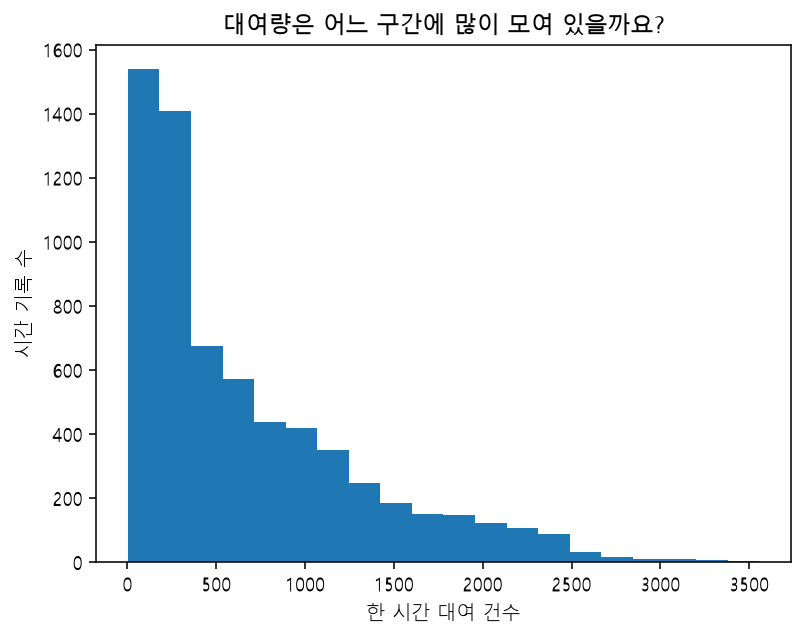

**코드 사용법과 결과 읽기**

- `plot(kind="hist", bins=20)`은 대여량 범위를 20개 구간으로 나누고 각 구간의 기록 수를 그립니다.
- 가로축은 대여 건수, 세로축은 그 구간에 속하는 시간 기록 수입니다.
- `xlabel()`, `ylabel()`, `title()`로 축 이름과 제목을 붙입니다. `show()`는 준비한 그래프를 표시합니다.

**관찰:** 평균이 중앙값보다 크고 대여량의 범위가 넓습니다.

**반영:** 학습 정답의 중앙값을 모든 시간에 똑같이 예측하는 방법을 비교 기준으로 둡니다. 입력을 전혀 보지 않는 이 방법보다 모델들이 덜 틀리는지 뒤에서 확인합니다.

### 1-5. 기온과 대여량의 상관계수 계산하기

상관계수는 두 숫자가 함께 증가하거나 감소하는 관계를 -1~1 사이의 숫자로 요약합니다. 여기서는 기온이 높은 기록에서 대여량도 많은 경향이 있는지 확인합니다.

| 상관계수 | 읽는 방법 |
| --- | --- |
| 양수 | 한쪽이 클수록 다른 쪽도 큰 경향 |
| 음수 | 한쪽이 클수록 다른 쪽은 작은 경향 |
| 0에 가까운 값 | 일정한 직선으로 설명되는 관계가 약함 |

절댓값이 1에 가까울수록 직선 관계가 뚜렷합니다. 0에 가깝다고 모든 관계가 없는 것은 아닙니다.

먼저 비교할 숫자 열 두 개를 고른 뒤 `corr()`를 붙입니다. `explore[["temperature", "rented_count"]]`는 기온과 대여량을 담은 표이고, `.corr()`는 이 두 열의 상관계수 표를 계산합니다. 아래 코드는 계산한 표를 `temperature_relation`에 저장한 뒤 출력합니다.

Python - 7

```
temperature_relation = explore[["temperature", "rented_count"]].corr()
display(temperature_relation)
```

실제 실행 결과

|  | temperature | rented_count |
| --- | --- | --- |
| temperature | 1.000000 | 0.596814 |
| rented_count | 0.596814 | 1.000000 |

**코드 사용법과 결과 읽기**

- `[["temperature", "rented_count"]]`는 두 열을 데이터프레임으로 선택합니다.
- `corr()`는 선택한 숫자 열의 상관계수를 담은 **데이터프레임**을 반환합니다. 기본 계산은 직선 관계를 요약하는 피어슨 상관계수입니다.
- 행 이름과 열 이름은 비교한 변수입니다. `temperature` 행과 `rented_count` 열이 만나는 칸을 읽으면 됩니다. 반대쪽 칸에도 같은 값이 나옵니다.
- 대각선의 1은 자기 자신과의 관계입니다. 기온과 대여량의 관계를 확인할 때는 대각선 밖의 값을 읽습니다.
- 기온과 대여 건수가 만나는 칸은 약 0.60입니다. 학습 기간에는 기온이 높을수록 대여가 많은 경향이 있었습니다. 이 숫자가 정확도 60%라는 뜻은 아닙니다.
- 상관계수가 높다고 원인이 증명되거나 예측이 정확하다는 뜻은 아닙니다.

상관계수의 숫자를 산점도와 함께 확인합니다. 같은 기온에서도 대여량이 다르면 기온 외의 입력도 검토할 근거가 됩니다.

Python

```
explore.plot(kind="scatter", x="temperature", y="rented_count", alpha=0.3)
plt.xlabel("기온(℃)")
plt.ylabel("한 시간 대여 건수")
plt.title("기온과 대여량의 관계")
plt.show()
```

실제 실행 결과

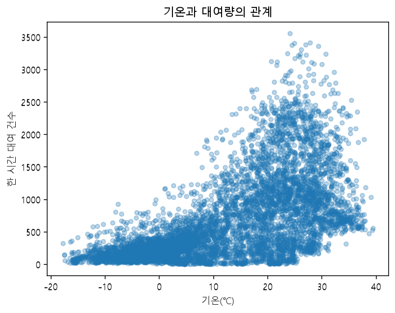

**코드 사용법과 결과 읽기**

- `kind="scatter"`는 두 숫자 열을 산점도로 표시합니다. 점 하나는 한 시간 기록입니다.
- `alpha=0.3`은 점이 겹친 부분을 읽기 쉽게 불투명도를 낮춥니다.
- 같은 기온에서도 대여량이 세로로 넓게 퍼집니다. 상관계수와 함께 읽으면 기온 하나만으로 구분하기 어려운 차이를 볼 수 있습니다.

**반영:** 기온 하나를 사용하는 선형 회귀를 첫 모델로 정합니다. 이 모델은 기온이 1℃ 높아질 때 예측값이 일정한 양만큼 달라지는 식을 학습합니다.

### 1-6. 기온이 비슷해도 시간대별로 다를까요?

기온만으로 충분하다면 비슷한 기온에서 대여량도 비슷할 것입니다. 15℃ 이상 20℃ 미만인 기록을 골라 시간대별 평균을 비교합니다. 다른 조건까지 같게 만든 실험은 아니므로 시간대의 인과 효과를 확인하는 과정은 아닙니다.

Python - 8

```
mild = explore[(explore["temperature"] >= 15) & (explore["temperature"] < 20)]
mild_by_hour = mild.groupby("hour")["rented_count"].agg(["count", "mean"])
display(mild_by_hour)
```

실제 실행 결과

| hour | count | mean |
| --- | --- | --- |
| 0 | 32 | 745.031250 |
| 1 | 34 | 594.411765 |
| 2 | 35 | 427.485714 |
| 3 | 39 | 306.076923 |
| 4 | 39 | 193.333333 |
| 5 | 38 | 218.157895 |
| 6 | 36 | 450.527778 |
| 7 | 39 | 894.692308 |
| 8 | 29 | 1372.241379 |
| 9 | 27 | 793.444444 |
| 10 | 30 | 713.933333 |
| 11 | 32 | 787.406250 |
| 12 | 28 | 890.750000 |
| 13 | 21 | 904.095238 |
| 14 | 18 | 920.444444 |
| 15 | 24 | 1015.000000 |
| 16 | 26 | 1157.615385 |
| 17 | 24 | 1375.000000 |
| 18 | 28 | 1812.357143 |
| 19 | 31 | 1494.096774 |
| 20 | 28 | 1376.000000 |
| 21 | 30 | 1403.900000 |
| 22 | 29 | 1221.241379 |
| 23 | 30 | 896.033333 |

**코드 사용법과 결과 읽기**

- 두 비교식은 각각 기온이 15 이상인지, 20 미만인지 확인합니다.
- `&`는 두 조건을 모두 만족한다는 뜻입니다. 각 조건을 괄호로 감쌉니다.
- `mild`는 조건에 맞는 행을 담은 데이터프레임입니다. 참/거짓 조건만 저장한 시리즈와 구분합니다.
- `groupby("hour")`는 같은 시각끼리 묶습니다. `agg(["count", "mean"])`는 묶음별 개수와 평균을 함께 계산해 표로 반환합니다.
- 비슷한 기온에서도 새벽과 퇴근 무렵의 평균이 다릅니다. 기록 수가 적은 시간인지도 함께 확인합니다.

**반영:** 기온에 시간대를 추가한 선형 회귀를 비교합니다. 이어서 학습 기간 전체에서도 시간대별 패턴을 확인합니다.

Python - 9

```
hour_average = explore.groupby("hour")["rented_count"].mean()
display(hour_average)
print("평균이 가장 높은 시각:", hour_average.idxmax())
```

실제 실행 결과

```
hour
0      517.933824
1      409.400735
2      293.738971
3      197.397059
4      128.213235
5      138.573529
6      280.154412
7      578.283088
8      962.437500
9      614.194853
10     495.286765
11     567.176471
12     660.257353
13     685.363971
14     702.963235
15     768.235294
16     863.702206
17    1062.363971
18    1426.169118
19    1152.455882
20    1040.860294
21    1010.735294
22     901.742647
23     653.801471
Name: rented_count, dtype: float64
```

```
평균이 가장 높은 시각: 18
```

**코드 사용법과 반환값**

- `explore.groupby("hour")`는 시각이 같은 행끼리 묶어 계산할 준비를 합니다.
- `["rented_count"].mean()`은 대여 건수 열을 선택해 **묶음별 평균**을 구합니다. 결과는 시각을 인덱스로 갖는 시리즈이며 `hour_average`에 저장합니다.
- `hour_average.idxmax()`는 가장 큰 평균이 있는 **시각**을 반환합니다. 가장 큰 평균 숫자를 구하는 `.max()`와 다릅니다.
- `display()`로 평균 열을 보고 `print()`로 최고 시각을 확인합니다.

시간대별 평균을 선으로 연결하여 값이 오르내리는 모양을 확인합니다.

Python

```
hour_average.plot(kind="line", marker="o")
plt.xlabel("시각(시)")
plt.ylabel("시간당 평균 대여 건수")
plt.title("시간대별 평균 대여량")
plt.show()
```

실제 실행 결과

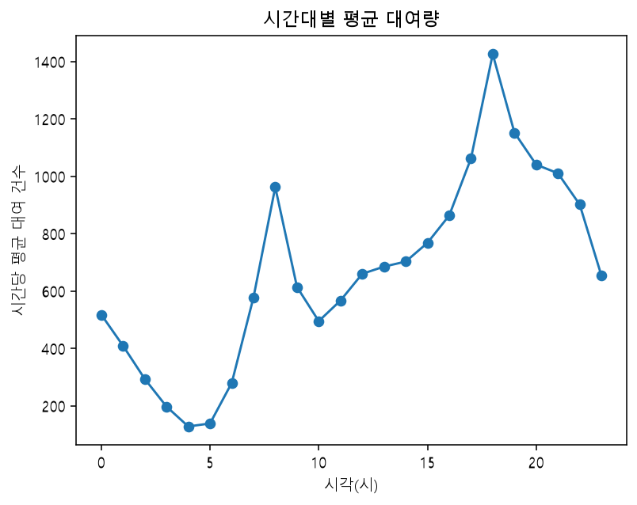

**코드 사용법과 결과 읽기**

- 시간대를 인덱스로 갖는 `hour_average`를 선으로 연결합니다. `marker="o"`는 각 평균 위치에 원을 표시합니다.
- 아침과 저녁의 봉우리를 확인합니다. 시각이 커질 때 평균이 일정하게 커지는 모양은 아니므로 직선만으로 설명하기 어려울 수 있습니다.

**관찰:** 시각이 커질수록 평균이 일정하게 증가하는 모양은 아닙니다. 아침에 높아졌다 낮아지고 저녁에 다시 높아집니다.

**반영:** 시각에 일정한 기울기를 곱하는 선형 회귀와, 시간 구간을 조건으로 나눌 수 있는 나무 모델을 모두 비교합니다.

### 1-7. 비가 오는 기록은 다를까요?

비가 없는 기록과 있는 기록의 개수, 평균 대여량을 비교합니다.

Python - 10

```
dry = explore[explore["rainfall"] == 0]
rain = explore[explore["rainfall"] > 0]
print("강수 없음:", len(dry), "개, 평균", dry["rented_count"].mean(), "건")
print("강수 있음:", len(rain), "개, 평균", rain["rented_count"].mean(), "건")
```

실제 실행 결과

```
강수 없음: 6099 개, 평균 706.736678143958 건
강수 있음: 429 개, 평균 167.65734265734267 건
```

**코드 사용법과 반환값**

- `explore["rainfall"] == 0`은 강수가 없는 행, `> 0`은 강수가 있는 행을 찾는 조건입니다.
- `표[조건]`의 결과인 두 표를 각각 `dry`와 `rain`에 저장합니다. 이 코드는 원자료를 삭제하지 않습니다.
- `len(dry)`와 `len(rain)`은 각 집단의 행 수, `["rented_count"].mean()`은 각 집단의 평균 대여 건수입니다.
- `print(값1, 값2, ...)`는 여러 값을 차례로 표시합니다. 집단의 크기와 평균을 함께 읽습니다.

**관찰:** 비가 있는 기록에서 평균 대여량이 낮습니다. 두 집단의 시간대와 계절 구성까지 같다는 뜻은 아니므로 이 차이를 강수의 인과 효과로 단정하지 않습니다.

**반영:** 기온과 시간대에 강수량을 추가한 모델을 비교합니다. 집단 비교에서는 강수 유무를 확인했지만 모델에는 원래 강수량 수치를 넣습니다.

### 1-8. 습도를 추가할 근거가 있을까요?

기온에서 사용한 계산을 습도에도 적용합니다. 선택할 열을 `humidity`와 `rented_count`로 바꾸고 같은 `corr()`를 사용합니다.

Python - 11

```
humidity_relation = explore[["humidity", "rented_count"]].corr()
display(humidity_relation)
```

실제 실행 결과

|  | humidity | rented_count |
| --- | --- | --- |
| humidity | 1.000000 | -0.147538 |
| rented_count | -0.147538 | 1.000000 |

**코드 사용법과 결과 읽기**

- `explore[["humidity", "rented_count"]]`는 현재 습도와 대여 건수 두 열을 선택한 데이터프레임입니다.
- `.corr()`로 계산한 상관계수 표를 `humidity_relation`에 저장하고 `display()`로 출력합니다.
- `humidity`와 `rented_count`가 만나는 칸은 약 -0.15입니다. 습도가 높을수록 대여량이 적은 방향이지만 직선 관계는 뚜렷하지 않습니다.
- 상관계수가 작다는 이유만으로 입력에서 바로 제외하지 않습니다. 아래에서는 구간별 평균을 확인하여 직선 하나로 요약하기 어려운 차이도 살펴봅니다.

#### 습도 구간별 평균도 함께 확인하기

습도를 세 구간으로 나누어 대여량의 개수와 평균을 확인합니다. 구간별 평균 차이는 입력 후보로 검토할 근거입니다. 다른 변수와 겹치는 정보일 수도 있으므로 반드시 필요한 변수라고 미리 결론 내리지 않습니다.

Python - 12

```
explore["humidity_group"] = pd.cut(
    explore["humidity"],
    bins=[0, 40, 70, 100],
    labels=["0~40%", "40% 초과~70%", "70% 초과~100%"],
    include_lowest=True
)
humidity_summary = explore.groupby("humidity_group", observed=True)["rented_count"].agg(["count", "mean"])
display(humidity_summary)
```

실제 실행 결과

| humidity_group | count | mean |
| --- | --- | --- |
| 0~40% | 1528 | 662.857330 |
| 40% 초과~70% | 3072 | 788.093750 |
| 70% 초과~100% | 1928 | 491.930498 |

**코드 사용법과 결과 읽기**

- `pd.cut(열, bins=경계값, labels=이름)`은 숫자를 구간으로 나눈 범주형 시리즈를 반환합니다.
- 기본적으로 오른쪽 경계를 포함합니다. 40은 첫 구간, 70은 둘째 구간입니다. `include_lowest=True`로 최솟값 0도 포함합니다.
- 구간을 `humidity_group`이라는 탐색용 열에 저장합니다. 글자로 된 이 구간은 모델 입력으로 사용하지 않습니다.
- `observed=True`는 실제 기록이 있는 구간만 집계하라는 뜻입니다.
- `agg(["count", "mean"])`로 구간별 개수와 평균을 구합니다. 중간 구간에서 평균이 높고 높은 습도 구간에서 낮아, 단순한 감소 관계만 있는 것은 아닙니다.

**반영:** 원래 숫자 형태의 습도를 추가 입력 후보로 둡니다. 습도를 제외한 선형 회귀와 포함한 선형 회귀를 비교하여 이 조합에서 오차가 어떻게 달라지는지 확인합니다.

### 1-9. 관찰한 내용을 분석 계획으로 옮기기

| 관찰 | 판단 | 코드에 반영할 내용 |
| --- | --- | --- |
| 대여량의 평균과 중앙값이 다름 | 대표값 하나로 설명하기 어려울 수 있음 | 중앙값 예측을 비교 기준으로 사용 |
| 기온과 대여량의 양의 관계 | 기온을 첫 입력으로 검토 | 기온 하나의 선형 회귀 |
| 비슷한 기온에서도 시간대별 평균이 다름 | 시간대가 추가 정보를 줄 수 있음 | 시간대 추가 |
| 강수 유무별 평균이 다름 | 강수량도 입력 후보 | 강수량 추가 |
| 습도 구간별 평균이 다름 | 습도가 추가 정보를 줄 가능성 | 습도 포함과 제외 비교 |
| 시간대별 평균이 일정하게 증가하지 않음 | 일정한 기울기의 식에 한계가 있을 수 있음 | 같은 네 입력으로 나무와 랜덤 포레스트 비교 |

여기서 변수 선택은 모든 열에서 최적 조합을 찾아낸다는 뜻이 아닙니다. 관찰한 근거가 있는 네 후보로 비교 범위를 정하는 것입니다. 나머지 변수가 쓸모없다고 판단한 것도 아닙니다.

## Part 2 - 모델에 사용할 데이터 준비하기

### 2-1. 결측값, 중복 행, 값의 범위 확인하기

빈칸이나 잘못된 값이 있으면 모델 학습 전에 처리 기준을 정해야 합니다. 기준은 학습 자료에서 정하고 평가 자료에도 동일하게 적용합니다.

Python - 13

```
display(train.isna().sum())
print("중복 행 수:", train.duplicated().sum())
print("시각 범위:", train["hour"].min(), "~", train["hour"].max())
print("습도 범위:", train["humidity"].min(), "~", train["humidity"].max())
print("최소 강수량:", train["rainfall"].min())
print("최소 대여 건수:", train["rented_count"].min())
```

실제 실행 결과

```
date               0
rented_count       0
hour               0
temperature        0
humidity           0
wind_speed         0
visibility         0
dew_point          0
solar_radiation    0
rainfall           0
snowfall           0
season             0
holiday            0
functioning_day    0
dtype: int64
```

```
중복 행 수: 0
시각 범위: 0 ~ 23
습도 범위: 0 ~ 98
최소 강수량: 0.0
최소 대여 건수: 2
```

**코드 사용법과 결과 읽기**

- `isna()`는 빈칸을 참으로 표시한 표를 반환합니다. `.sum()`을 붙이면 참을 1로 세어 열별 결측 개수를 구합니다.
- `duplicated()`는 앞에서 나온 행과 완전히 같은 행인지 표시합니다. `.sum()`은 첫 행을 제외한 중복 행 수입니다.
- `min()`과 `max()`는 각 열의 최솟값과 최댓값입니다. 시각은 0~23, 습도는 0~100 범위인지 확인합니다.
- 이 학습 자료에는 결측과 완전 중복이 없어 채우기나 중복 삭제가 필요하지 않습니다.
- 대여량이 높다는 이유만으로 오류라고 판단하거나 삭제하지 않습니다. 강수량과 대여 건수의 음수 여부도 확인합니다.

### 2-2. 입력 데이터와 정답 데이터

한 행의 시간대, 기온, 습도, 강수량과 같은 행의 실제 대여 건수가 한 쌍입니다.

| 단계 | 사용하는 자료 | 정답의 역할 |
| --- | --- | --- |
| 학습 | 학습 입력과 학습 정답 | 입력과 정답의 관계를 배우기 |
| 예측 | 학습이 끝난 모델에 입력만 전달 | 정답을 전달하지 않음 |
| 평가 | 예측값과 평가 정답 비교 | 오차 계산 |

정답이 없는 새 자료도 예측할 수 있지만 오차 계산에는 실제 정답이 필요합니다. 날짜는 기간을 나누는 데만 사용하고, 탐색용 습도 구간은 모델 입력에 넣지 않습니다.

Python - 14

```
X_train = train[["hour", "temperature", "humidity", "rainfall"]]
y_train = train["rented_count"]
X_test = test[["hour", "temperature", "humidity", "rainfall"]]
y_test = test["rented_count"]
display(X_train.head())
display(y_train.head())
```

실제 실행 결과

|  | hour | temperature | humidity | rainfall |
| --- | --- | --- | --- | --- |
| 0 | 0 | -5.2 | 37 | 0.0 |
| 1 | 1 | -5.5 | 38 | 0.0 |
| 2 | 2 | -6.0 | 39 | 0.0 |
| 3 | 3 | -6.2 | 40 | 0.0 |
| 4 | 4 | -6.0 | 36 | 0.0 |

```
0    254
1    204
2    173
3    107
4     78
Name: rented_count, dtype: int64
```

**코드 사용법과 결과 읽기**

- 여러 열을 고르는 `[[...]]`는 데이터프레임을, 한 열을 고르는 `["rented_count"]`는 시리즈를 반환합니다.
- `X_train`과 `X_test`는 입력 표, `y_train`과 `y_test`는 정답 열입니다.
- 입력과 정답은 같은 원래 행 순서를 유지합니다. 표시된 결과에서 인덱스가 같은 행끼리 한 쌍입니다.
- 정답인 대여 건수를 입력에 포함하지 않습니다. 네 후보를 준비한 뒤 모델마다 필요한 입력 열만 고릅니다.
- 학습 입력과 평가 입력은 같은 열 이름과 순서여야 합니다.

학습 자료와 평가 자료를 나눈 뒤 각각의 입력과 정답을 대응시킵니다. 같은 가로줄에 있는 네 입력과 대여 건수가 한 쌍입니다.

[figure not shown]

학습에는 입력과 정답이 함께 필요합니다. 학습이 끝난 모델에는 입력만 전달하여 예측하고, 그 뒤 정답과 비교해 오차를 계산합니다.

[figure not shown]

## Part 3 - 모델링, 평가, 인사이트 도출

### 3-1. 중앙값으로 예측하는 기준 만들기

평균 절대 오차(MAE)는 각 기록의 실제값과 예측값 차이에서 부호를 없앤 뒤 평균한 값입니다. 실제값이 100, 200이고 예측값이 80, 230이면 차이의 크기는 20, 30이며 MAE는 25건입니다.

먼저 학습 정답의 중앙값을 모든 시간에 똑같이 답합니다. 입력을 전혀 사용하지 않는 이 방법을 기준으로 둡니다.

Python - 15

```
middle = y_train.median()
baseline_test_pred = [middle] * len(y_test)
baseline_test_mae = mean_absolute_error(y_test, baseline_test_pred)
print("항상 예측할 값:", middle, "건")
print("중앙값 기준 MAE:", baseline_test_mae, "건")
```

실제 실행 결과

```
항상 예측할 값: 424.0 건
중앙값 기준 MAE: 607.6334537945277 건
```

**코드 사용법과 반환값**

- `y_train.median()`은 **학습 정답**의 중앙값 하나를 반환합니다. 평가 정답으로 기준값을 만들지 않습니다.
- `[middle] * len(y_test)`는 같은 중앙값을 평가 행 수만큼 반복한 **리스트**입니다. 모든 시간에 같은 값을 예측하는 기준입니다.
- `mean_absolute_error(실제값, 예측값)`은 행별 차이의 절댓값을 평균해 숫자 하나를 반환합니다. 실제값과 예측값의 개수, 순서를 맞춰야 합니다.
- 계산한 오차는 `baseline_test_mae`에 저장합니다. 여기서는 단위가 건이며, 작을수록 덜 틀렸다는 뜻입니다.

### 3-2. 기온과의 관계를 첫 모델에 반영하기

기온과 대여량의 양의 관계를 첫 모델로 연결합니다. 선형 회귀는 `예측 대여량 = 절편 + 기울기 × 기온` 형태의 식을 학습합니다. 실제값과 예측값 차이를 제곱해 더한 값이 작아지도록 계수를 정합니다. 학습의 제곱 오차와 평가의 MAE는 서로 다른 계산입니다.

Python - 16

```
linear_temp = LinearRegression()
linear_temp.fit(X_train[["temperature"]], y_train)
print("기울기:", linear_temp.coef_[0])
print("절편:", linear_temp.intercept_)
```

실제 실행 결과

```
기울기: 28.87520057651711
절편: 311.5448661503258
```

**코드 사용법과 반환값**

- `LinearRegression()`은 아직 학습하지 않은 선형 회귀 모델을 만듭니다. 그 모델을 `linear_temp`에 저장합니다.
- `모델.fit(입력, 정답)`은 규칙을 학습하고 학습된 모델 자신을 반환합니다. 예측값 배열을 반환하는 함수는 아닙니다.
- `X_train[["temperature"]]`는 열 하나도 표 형태로 고릅니다. 이중 대괄호를 쓰는 이유입니다.
- 학습 뒤 `coef_`에는 계수가 배열로 저장됩니다. `[0]`은 첫 계수입니다. `intercept_`는 절편입니다. 둘 다 속성이므로 뒤에 `()`를 붙이지 않습니다.

`fit(입력, 정답)`은 관계를 학습하고, `predict(입력)`은 학습한 관계로 답을 계산합니다. 평가 정답은 예측이 끝난 뒤 비교에만 사용합니다.

Python - 17

```
temp_test_pred = linear_temp.predict(X_test[["temperature"]])
temp_test_mae = mean_absolute_error(y_test, temp_test_pred)
print("기온 모델 MAE:", temp_test_mae, "건")
```

실제 실행 결과

```
기온 모델 MAE: 458.0993974996406 건
```

**코드 사용법과 반환값**

- `linear_temp.predict(입력표)`는 각 행의 예측값이 담긴 **배열**을 반환합니다. 평가 입력에도 학습 때와 같은 `temperature` 열 하나를 줍니다.
- 반환된 예측을 `temp_test_pred`에 저장합니다. `predict()`에는 실제 정답 `y_test`를 전달하지 않습니다.
- `mean_absolute_error(y_test, temp_test_pred)`는 예측을 만든 뒤 정답과 비교해 평균 오차 숫자 하나를 반환합니다.
- `print()`로 그 오차를 표시합니다. `fit()`은 학습, `predict()`는 예측, 오차 함수는 평가라는 역할 차이를 구분합니다.

선형 회귀는 실제값과 직선의 예측값 차이를 제곱해 더한 값이 작아지도록 기울기와 절편을 찾습니다. 아래는 일반적인 입력 x와 정답 y로 설명한 원리입니다. 점에서 직선까지의 세로 차이가 잔차입니다.

[figure not shown]

### 3-3. 비슷한 기온에서도 달랐던 시간대 추가하기

15℃ 이상 20℃ 미만에서도 시간대별 대여량이 달랐습니다. 기온만으로 구별하지 못한 차이를 알려 주기 위해 시간대를 추가합니다.

모델 종류와 자료는 유지하고 입력만 늘립니다. 다만 시각을 0~23의 숫자로 넣는 선형 회귀는 시간이 1시간 늘 때 예측값이 일정한 양만큼 변한다고 가정합니다. 아침과 저녁의 두 봉우리를 충분히 표현하는 것은 아닙니다.

Python - 18

```
linear_time = LinearRegression()
linear_time.fit(X_train[["temperature", "hour"]], y_train)
time_test_pred = linear_time.predict(X_test[["temperature", "hour"]])
time_test_mae = mean_absolute_error(y_test, time_test_pred)
print("시간대 추가 전 MAE:", temp_test_mae)
print("시간대 추가 후 MAE:", time_test_mae)
```

실제 실행 결과

```
시간대 추가 전 MAE: 458.0993974996406
시간대 추가 후 MAE: 386.1096546915266
```

**코드 사용법과 결과 읽기**

- `LinearRegression()`으로 새로운 모델을 만들고 `fit()`에 기온과 시간대 두 열을 전달합니다.
- `fit()`은 학습을 마친 모델 자신을 반환합니다. 모델 변수에 학습 결과가 저장됩니다.
- `predict()`에는 같은 두 열을 같은 순서로 전달합니다. 반환값은 각 행의 예측값이 담긴 배열입니다.
- MAE는 숫자 하나입니다. 두 출력의 차이는 같은 선형 회귀에서 시간대 입력을 추가한 비교 결과입니다.
- 차이가 줄어도 시간대의 인과 효과나 모든 미래 기간의 개선이 증명된 것은 아닙니다.

### 3-4. 강수 유무에서 발견한 차이 반영하기

강수가 있는 기록의 평균 대여량이 낮았다는 관찰을 반영하여 강수량을 추가합니다. 모델에는 강수 여부의 글자 대신 원래 강수량(mm)을 넣습니다.

Python - 19

```
linear_rain = LinearRegression()
linear_rain.fit(X_train[["temperature", "hour", "rainfall"]], y_train)
rain_test_pred = linear_rain.predict(X_test[["temperature", "hour", "rainfall"]])
rain_test_mae = mean_absolute_error(y_test, rain_test_pred)
print("강수량 추가 전 MAE:", time_test_mae)
print("강수량 추가 후 MAE:", rain_test_mae)
```

실제 실행 결과

```
강수량 추가 전 MAE: 386.1096546915266
강수량 추가 후 MAE: 373.3413218297335
```

**코드 사용법과 결과 읽기**

- 입력이 기온, 시간대, 강수량의 세 열로 늘었습니다. 학습과 평가의 정답은 앞과 같습니다.
- `fit()`에는 입력과 정답을, `predict()`에는 입력만 넣습니다. `mean_absolute_error()`에서 예측 결과와 정답을 비교합니다.
- **결과 읽기:** 앞의 시간대 추가 모델과 비교하여 강수량을 더했을 때 이 기간의 오차가 줄었는지 확인합니다.
- 이 비교에서 바꾼 것은 강수량 입력입니다. 동시에 모델 종류까지 바꾸지 않아 비교 목적을 분명하게 합니다.

### 3-5. 습도가 추가 정보를 주는지 확인하기

습도 구간별 평균 차이를 근거로 습도를 후보에 포함했습니다. 이제 세 입력 모델과 습도를 추가한 네 입력 모델의 오차를 비교합니다. 구간별 차이는 후보를 정하는 근거이고, 아래 비교는 그 후보를 실제 예측에 반영한 결과를 확인하는 과정입니다.

Python - 20

```
linear_four = LinearRegression()
linear_four.fit(X_train, y_train)
four_test_pred = linear_four.predict(X_test)
four_test_mae = mean_absolute_error(y_test, four_test_pred)
print("습도 제외 MAE:", rain_test_mae)
print("습도 포함 MAE:", four_test_mae)
```

실제 실행 결과

```
습도 제외 MAE: 373.3413218297335
습도 포함 MAE: 346.477753234996
```

**코드 사용법과 결과 읽기**

- `X_train`은 시간대, 기온, 습도, 강수량 네 열입니다. 탐색용 습도 구간 이름은 입력에 넣지 않습니다.
- 앞 모델과 같은 자료, 같은 선형 회귀를 사용하고 습도 수치를 추가했습니다.
- 이 평가 기간에서는 습도를 포함한 모델의 MAE가 더 작습니다. 이는 특정 조합과 기간의 결과입니다.
- 계수의 크기는 입력의 단위에 영향을 받으므로 변수 중요도로 직접 비교하지 않습니다.
- 평가 오차를 반복해서 보며 최적 입력을 고른 것이 아니라, EDA 뒤 미리 정한 비교를 확인한 것입니다.

입력이 여러 개이면 각 입력에 계수를 곱한 뒤 절편과 함께 더합니다. 아래의 두 입력 회귀평면은 이 원리를 설명합니다. 입력이 네 개여도 계산 방식은 같습니다.

[figure not shown]

Python - 21

```
input_comparison = pd.DataFrame({
    "입력": ["기온", "기온, 시간대", "기온, 시간대, 강수량", "기온, 시간대, 강수량, 습도"],
    "평가 MAE": [temp_test_mae, time_test_mae, rain_test_mae, four_test_mae]
})
display(input_comparison)
```

실제 실행 결과

|  | 입력 | 평가 MAE |
| --- | --- | --- |
| 0 | 기온 | 458.099397 |
| 1 | 기온, 시간대 | 386.109655 |
| 2 | 기온, 시간대, 강수량 | 373.341322 |
| 3 | 기온, 시간대, 강수량, 습도 | 346.477753 |

**코드 사용법과 결과 읽기**

- `pd.DataFrame({열 이름: 값 목록})`은 같은 길이의 목록을 열로 묶어 표를 만듭니다.
- 입력 이름 목록과 MAE 목록은 같은 순서로 적습니다.
- 각 행에서 앞 행보다 어떤 입력이 추가되었고 오차가 어떻게 달라졌는지 읽습니다.
- 여기까지는 모델을 선형 회귀로 고정한 비교입니다. 다음에는 네 입력을 고정하고 모델 종류를 바꿉니다.

### 3-6. 시간대의 복잡한 패턴을 나무로 표현하기

시간대별 평균은 아침에 높아졌다가 낮아지고 저녁에 다시 높아졌습니다. 시간에 일정한 계수를 곱하는 방식으로는 이런 굴곡을 충분히 표현하기 어렵습니다.

의사결정나무는 시각이나 기온이 특정 값 이하인지 질문하며 기록을 나눕니다. 각 마지막 그룹의 학습 정답 평균을 예측값으로 사용하므로 서로 다른 구간에 서로 다른 값을 줄 수 있습니다. 깊이 6은 평가 전에 정한 설정입니다.

Python - 22

```
tree = DecisionTreeRegressor(max_depth=6, random_state=0)
tree.fit(X_train, y_train)
tree_test_pred = tree.predict(X_test)
tree_test_mae = mean_absolute_error(y_test, tree_test_pred)
print("네 입력 선형 회귀 MAE:", four_test_mae)
print("의사결정나무 MAE:", tree_test_mae)
```

실제 실행 결과

```
네 입력 선형 회귀 MAE: 346.477753234996
의사결정나무 MAE: 291.24775260695543
```

**코드 사용법과 결과 읽기**

- `DecisionTreeRegressor()`는 숫자를 예측하는 나무를 만듭니다. `max_depth=6`은 이어서 나눌 수 있는 최대 깊이입니다.
- `random_state=0`은 무작위 선택을 재현하기 위한 설정입니다. 정확도를 0으로 설정하는 뜻이 아닙니다.
- 입력 네 열과 정답은 앞의 선형 회귀와 같습니다. 이번에는 모델 종류를 바꿨습니다.
- 나무는 네 입력 모두에서 구간별 관계를 표현하므로 오차 차이를 시간대 하나의 효과라고 해석하지 않습니다.
- 같은 마지막 그룹에 들어간 기록은 실제값이 달라도 같은 예측값을 받습니다. 깊이가 제한되면 큰 수요를 충분히 구별하지 못할 수 있습니다.

회귀나무는 조건 질문을 따라 가지를 이동하고, 마지막 그룹에 있는 학습 정답의 평균을 예측합니다. 아래는 실제 서울 자전거 나무가 아닌 일반적인 회귀나무의 예시입니다.

[figure not shown]

### 3-7. 여러 나무의 예측을 평균하기

나무 한 개는 어떤 기록으로 학습했는지에 따라 달라질 수 있습니다. 랜덤 포레스트는 학습 기록을 중복을 허용하여 무작위로 다시 뽑아 여러 나무를 만들고 예측을 평균합니다. 세 나무가 600, 800, 700건을 예측하면 평균인 700건을 답하는 방식입니다. 아래에서는 나무 100개를 사용합니다.

Python - 23

```
forest = RandomForestRegressor(n_estimators=100, max_depth=6, random_state=0)
forest.fit(X_train, y_train)
forest_test_pred = forest.predict(X_test)
forest_test_mae = mean_absolute_error(y_test, forest_test_pred)
print("의사결정나무 MAE:", tree_test_mae)
print("랜덤 포레스트 MAE:", forest_test_mae)
```

실제 실행 결과

```
의사결정나무 MAE: 291.24775260695543
랜덤 포레스트 MAE: 266.37161554600044
```

**코드 사용법과 결과 읽기**

- `n_estimators=100`은 나무의 개수, `max_depth=6`은 각 나무의 최대 깊이입니다. 평가 점수를 보고 바꾸지 않는 설정입니다.
- `fit()`은 여러 나무를 학습하고 `predict()`는 나무들의 예측을 평균한 배열을 반환합니다.
- 별도 설정이 없으면 scikit-learn의 회귀 랜덤 포레스트는 각 분할에서 전체 입력을 후보로 검토합니다. 여기서 나무마다 차이를 만드는 주요 무작위성은 학습 기록의 재추출입니다.
- 여러 나무를 평균한다고 언제나 더 정확한 것은 아닙니다. 같은 평가 자료에서 계산한 두 MAE를 비교합니다.

같은 입력을 서로 다르게 학습한 여러 나무에 전달하고 숫자 예측을 평균합니다. 아래는 세 나무로 설명한 일반적인 원리이며 실제 코드에서는 나무 100개를 사용합니다.

[figure not shown]

Python - 24

```
comparison = pd.DataFrame({
    "방법": ["중앙값 기준", "기온 선형 회귀", "시간대 추가 선형 회귀", "강수량 추가 선형 회귀", "습도 추가 선형 회귀", "의사결정나무", "랜덤 포레스트"],
    "평가 MAE": [baseline_test_mae, temp_test_mae, time_test_mae, rain_test_mae, four_test_mae, tree_test_mae, forest_test_mae]
})
display(comparison)
```

실제 실행 결과

|  | 방법 | 평가 MAE |
| --- | --- | --- |
| 0 | 중앙값 기준 | 607.633454 |
| 1 | 기온 선형 회귀 | 458.099397 |
| 2 | 시간대 추가 선형 회귀 | 386.109655 |
| 3 | 강수량 추가 선형 회귀 | 373.341322 |
| 4 | 습도 추가 선형 회귀 | 346.477753 |
| 5 | 의사결정나무 | 291.247753 |
| 6 | 랜덤 포레스트 | 266.371616 |

**코드 사용법과 결과 읽기**

- 모든 행은 같은 평가 기간에서 계산한 MAE이며 단위는 건입니다.
- 선형 회귀 네 행에서는 입력 추가의 결과를 읽습니다. 네 입력 선형 회귀, 나무, 랜덤 포레스트에서는 같은 입력으로 모델을 바꾼 결과를 읽습니다.
- 작은 숫자가 이 평가 기간에서 덜 틀린 방법입니다. 모든 미래 기간의 순위로 일반화하지 않습니다.
- 비교 후 입력이나 모델 설정을 다시 고르거나 점수를 높이기 위해 반복해서 바꾸지 않습니다.

#### 실제값과 예측값 비교: 기온 선형 회귀

점 하나는 같은 평가 자료의 한 시간 기록입니다. 가로축은 실제 대여 건수, 세로축은 예측 대여 건수입니다. 네 모델의 축 범위를 같게 두고 점선 주변으로 얼마나 모이는지 비교합니다.

Python

```
plt.figure(figsize=(6, 6))
plt.scatter(y_test, temp_test_pred, alpha=0.3)
plt.plot([-600, 3500], [-600, 3500], "--", color="gray")
plt.xlim(-600, 3500)
plt.ylim(-600, 3500)
plt.xlabel("실제 대여 건수")
plt.ylabel("예측 대여 건수")
plt.title("실제값 vs 예측값: 기온 선형 회귀")
plt.show()
```

실제 실행 결과

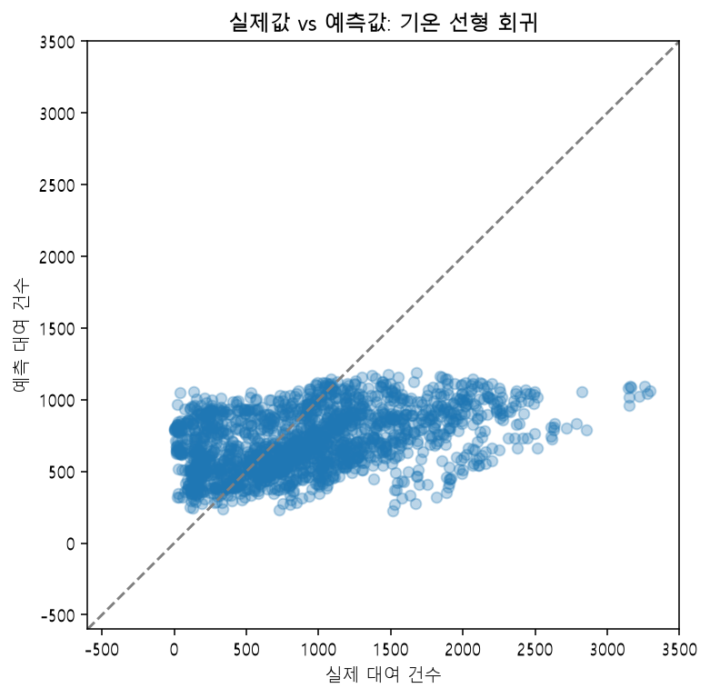

**코드 사용법과 결과 읽기**

- `scatter(실제값, 예측값)`은 한 시간의 실제값과 예측값을 점 하나로 나타냅니다.
- 회색 점선은 실제값과 예측값이 같은 위치입니다. 점선에 가까울수록 오차가 작습니다. 아래쪽은 실제보다 적게, 위쪽은 실제보다 많이 예측한 기록입니다.
- `xlim()`과 `ylim()`으로 네 그림의 축 범위를 같게 두었습니다. 음수 예측도 숨기지 않고 보여 줍니다.
- 나무 한 개는 같은 마지막 그룹에 같은 예측값을 주므로 점이 가로 띠처럼 모일 수 있습니다.

#### 실제값과 예측값 비교: 네 입력 선형 회귀

기온 하나만 사용했을 때와 비교합니다. 음수 예측도 숨기지 않고 표시합니다.

Python

```
plt.figure(figsize=(6, 6))
plt.scatter(y_test, four_test_pred, alpha=0.3)
plt.plot([-600, 3500], [-600, 3500], "--", color="gray")
plt.xlim(-600, 3500)
plt.ylim(-600, 3500)
plt.xlabel("실제 대여 건수")
plt.ylabel("예측 대여 건수")
plt.title("실제값 vs 예측값: 네 입력 선형 회귀")
plt.show()
```

실제 실행 결과

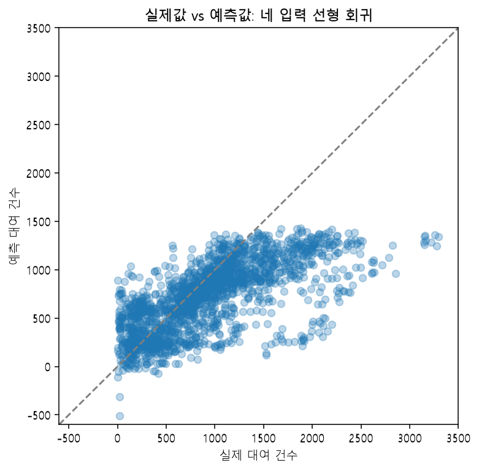

**코드 사용법과 결과 읽기**

- `scatter(실제값, 예측값)`은 한 시간의 실제값과 예측값을 점 하나로 나타냅니다.
- 회색 점선은 실제값과 예측값이 같은 위치입니다. 점선에 가까울수록 오차가 작습니다. 아래쪽은 실제보다 적게, 위쪽은 실제보다 많이 예측한 기록입니다.
- `xlim()`과 `ylim()`으로 네 그림의 축 범위를 같게 두었습니다. 음수 예측도 숨기지 않고 보여 줍니다.
- 나무 한 개는 같은 마지막 그룹에 같은 예측값을 주므로 점이 가로 띠처럼 모일 수 있습니다.

#### 실제값과 예측값 비교: 의사결정나무

같은 마지막 그룹에 도착한 기록에 같은 값을 주어 점들이 가로 띠처럼 보일 수 있습니다. 실제 대여량이 큰 기록을 충분히 따라가는지도 살펴봅니다.

Python

```
plt.figure(figsize=(6, 6))
plt.scatter(y_test, tree_test_pred, alpha=0.3)
plt.plot([-600, 3500], [-600, 3500], "--", color="gray")
plt.xlim(-600, 3500)
plt.ylim(-600, 3500)
plt.xlabel("실제 대여 건수")
plt.ylabel("예측 대여 건수")
plt.title("실제값 vs 예측값: 의사결정나무")
plt.show()
```

실제 실행 결과

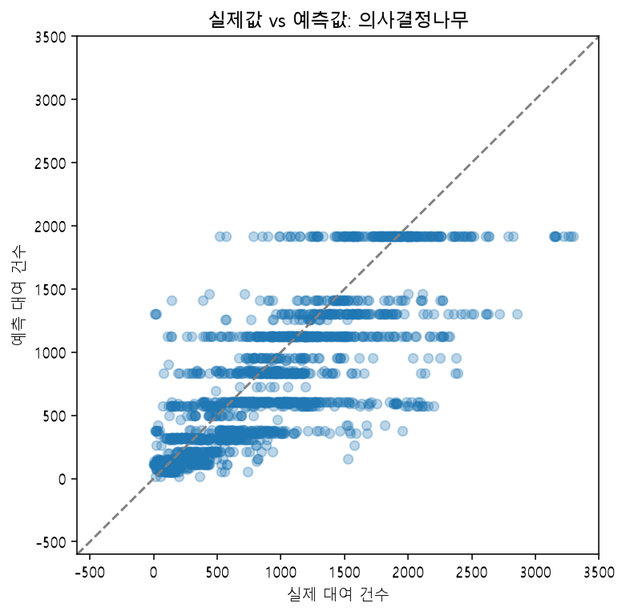

**코드 사용법과 결과 읽기**

- `scatter(실제값, 예측값)`은 한 시간의 실제값과 예측값을 점 하나로 나타냅니다.
- 회색 점선은 실제값과 예측값이 같은 위치입니다. 점선에 가까울수록 오차가 작습니다. 아래쪽은 실제보다 적게, 위쪽은 실제보다 많이 예측한 기록입니다.
- `xlim()`과 `ylim()`으로 네 그림의 축 범위를 같게 두었습니다. 음수 예측도 숨기지 않고 보여 줍니다.
- 나무 한 개는 같은 마지막 그룹에 같은 예측값을 주므로 점이 가로 띠처럼 모일 수 있습니다.

#### 실제값과 예측값 비교: 랜덤 포레스트

여러 나무의 평균으로 예측하므로 한 나무보다 예측값이 다양해집니다. 큰 실제값에서도 점선과 차이가 남는지 확인합니다.

Python

```
plt.figure(figsize=(6, 6))
plt.scatter(y_test, forest_test_pred, alpha=0.3)
plt.plot([-600, 3500], [-600, 3500], "--", color="gray")
plt.xlim(-600, 3500)
plt.ylim(-600, 3500)
plt.xlabel("실제 대여 건수")
plt.ylabel("예측 대여 건수")
plt.title("실제값 vs 예측값: 랜덤 포레스트")
plt.show()
```

실제 실행 결과

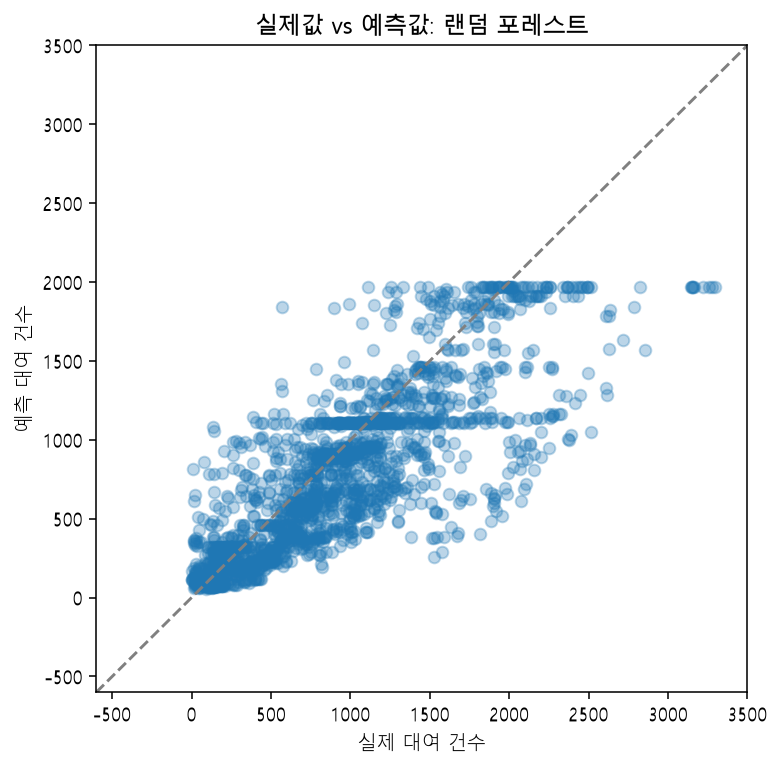

**코드 사용법과 결과 읽기**

- `scatter(실제값, 예측값)`은 한 시간의 실제값과 예측값을 점 하나로 나타냅니다.
- 회색 점선은 실제값과 예측값이 같은 위치입니다. 점선에 가까울수록 오차가 작습니다. 아래쪽은 실제보다 적게, 위쪽은 실제보다 많이 예측한 기록입니다.
- `xlim()`과 `ylim()`으로 네 그림의 축 범위를 같게 두었습니다. 음수 예측도 숨기지 않고 보여 줍니다.
- 나무 한 개는 같은 마지막 그룹에 같은 예측값을 주므로 점이 가로 띠처럼 모일 수 있습니다.

### 3-8. 평균 오차 뒤에 가려진 기록 확인하기

구간별 평균을 답하는 나무의 특성을 더 살펴보기 위해 나무 예측을 자세히 확인합니다. 가장 좋은 모델을 자동 선택했다는 뜻은 아닙니다.

평균 오차만 보면 어떤 기록에서 크게 틀렸는지 알 수 없습니다. 같은 행에 실제값, 예측값, 차이의 크기를 놓습니다.

Python - 25

```
check = test[["date", "hour", "temperature", "humidity", "rainfall", "rented_count"]].copy()
check["predicted"] = tree_test_pred
check["absolute_error"] = (check["rented_count"] - check["predicted"]).abs()
display(check.head())
```

실제 실행 결과

|  | date | hour | temperature | humidity | rainfall | rented_count | predicted | absolute_error |
| --- | --- | --- | --- | --- | --- | --- | --- | --- |
| 6576 | 2018-09-01 | 0 | 23.2 | 83 | 0.0 | 1075 | 851.651685 | 223.348315 |
| 6577 | 2018-09-01 | 1 | 22.7 | 83 | 0.0 | 975 | 851.651685 | 123.348315 |
| 6578 | 2018-09-01 | 2 | 22.0 | 86 | 0.0 | 785 | 499.927273 | 285.072727 |
| 6579 | 2018-09-01 | 3 | 21.6 | 87 | 0.0 | 514 | 318.537037 | 195.462963 |
| 6580 | 2018-09-01 | 4 | 21.2 | 88 | 0.0 | 338 | 318.537037 | 19.462963 |

**코드 사용법과 반환값**

- `test[[...]].copy()`는 평가 표에서 필요한 열들을 고른 뒤 복사한 새 표를 반환합니다.
- `check["predicted"] = tree_test_pred`는 예측 배열을 새 열에 추가합니다. `predict()`가 평가 입력의 행 순서대로 값을 반환했으므로 같은 행끼리 대응합니다.
- 실제값 열에서 예측값 열을 빼면 행별 차이입니다. `.abs()`는 그 차이에서 부호를 없앤 **절댓값 열**을 반환합니다.
- `check.head()`와 `display()`로 앞 다섯 기록의 실제값, 예측값, 오차를 나란히 봅니다.

큰 오차가 난 기록의 날짜, 시각, 날씨와 실제값을 함께 확인합니다. 오차가 크다는 이유만으로 원자료 오류라고 판단하거나 삭제하지 않습니다.

Python - 26

```
error_order = check.sort_values("absolute_error", ascending=False)
big_misses = error_order.head(5)
display(big_misses)
```

실제 실행 결과

|  | date | hour | temperature | humidity | rainfall | rented_count | predicted | absolute_error |
| --- | --- | --- | --- | --- | --- | --- | --- | --- |
| 7688 | 2018-10-17 | 8 | 9.2 | 68 | 0.0 | 2202 | 576.880000 | 1625.120000 |
| 8418 | 2018-11-16 | 18 | 9.9 | 74 | 0.0 | 1956 | 378.800000 | 1577.200000 |
| 7712 | 2018-10-18 | 8 | 8.5 | 77 | 0.0 | 2154 | 576.880000 | 1577.120000 |
| 6848 | 2018-09-12 | 8 | 18.2 | 56 | 0.0 | 2391 | 833.738197 | 1557.261803 |
| 7664 | 2018-10-16 | 8 | 10.4 | 63 | 0.0 | 2134 | 576.880000 | 1557.120000 |

**코드 사용법과 반환값**

- `표.sort_values("기준열", ascending=False)`는 기준열의 값이 큰 순서로 정렬한 새 표를 반환합니다. 원래 `check`의 행 순서는 바꾸지 않습니다.
- `error_order.head(5)`는 정렬한 표의 앞 다섯 행을 반환합니다. 따라서 오차가 가장 큰 다섯 기록입니다.
- 결과를 `big_misses`에 저장하고 `display()`로 봅니다. `head(5)`만 원래 표에 적용하면 단순히 처음 기록 다섯 개가 되므로 정렬이 먼저입니다.

### 3-9. 어떤 시각의 예측을 더 확인해야 할까요?

EDA에서 시간대별 평균 대여량을 구한 방법을 이번에는 절대 오차에 적용합니다. 이용량이 많은 시간과 오차가 큰 시간이 같은지도 읽습니다.

Python - 27

```
hour_error = check.groupby("hour")["absolute_error"].mean()
display(hour_error)
print("평균 오차가 가장 큰 시각:", hour_error.idxmax())
```

실제 실행 결과

```
hour
0     242.738366
1     196.592019
2     113.790273
3      93.490111
4      75.767241
5      77.723994
6     206.859683
7     420.555368
8     829.844102
9     299.747331
10    175.225011
11    188.821127
12    193.886998
13    235.264684
14    232.870395
15    286.985099
16    284.916034
17    303.750537
18    802.071781
19    449.226211
20    344.526826
21    322.063429
22    382.825434
23    217.666074
Name: absolute_error, dtype: float64
```

```
평균 오차가 가장 큰 시각: 8
```

**코드 사용법과 반환값**

- `check.groupby("hour")`는 평가 기록을 시각별로 묶습니다.
- `["absolute_error"].mean()`은 묶음마다 절대 오차의 평균을 구합니다. 결과는 시각을 인덱스로 갖는 **시리즈**입니다.
- `hour_error.idxmax()`는 평균 오차가 가장 큰 시각을 반환합니다. `.max()`를 쓰면 시각이 아니라 가장 큰 오차 숫자가 나옵니다.
- `display()`로 모든 시각을 확인하고 `print()`로 가장 큰 오차의 시각을 표시합니다.

시간대별 오차를 막대로 확인합니다. 전체 평균만으로 모든 시간대의 예측 품질을 판단하기 어려운 이유를 읽을 수 있습니다.

Python

```
hour_error.plot(kind="bar")
plt.xlabel("시각(시)")
plt.ylabel("평균 절대 오차(건)")
plt.title("어느 시간대의 예측을 더 확인해야 할까요?")
plt.show()
```

실제 실행 결과

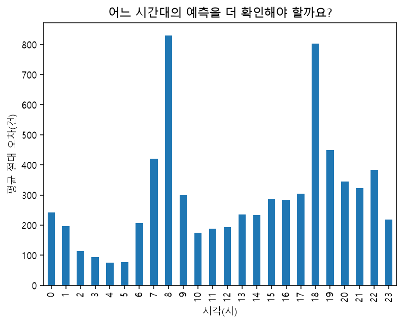

**코드 사용법과 결과 읽기**

- `hour_error`는 시간대별 평균 절대 오차입니다. `plot(kind="bar")`는 이를 막대로 나타냅니다.
- 막대가 높을수록 그 시간대의 평균 오차가 큽니다. 평균 대여량 그래프와 오차 그래프의 세로축을 구분합니다.

시간대별 오차는 활용할 때 주의할 조건과 다음 분석에서 확인할 문제를 찾는 근거입니다. 이 평가 기록을 반복해서 보며 현재 모델을 조정하는 데 사용하지 않습니다.

### 3-10. 정답이 없는 조건으로 예측하기

18시, 기온 20℃, 습도 60%, 강수량 0mm를 입력합니다. 학습이 끝난 모델에는 입력만 주면 됩니다. 실제 정답이 없으므로 예상값은 구할 수 있지만 이 한 건의 오차는 계산할 수 없습니다.

Python - 28

```
new_data = pd.DataFrame({
    "hour": [18], "temperature": [20], "humidity": [60], "rainfall": [0]
})
new_prediction = tree.predict(new_data)
print("의사결정나무의 예측:", new_prediction[0])
```

실제 실행 결과

```
의사결정나무의 예측: 1915.9382183908046
```

**코드 사용법과 반환값**

- `pd.DataFrame({...})`으로 예측할 조건 한 행을 만듭니다. 각 값에 `[18]`처럼 대괄호를 붙여 열에 넣을 값 목록임을 표시합니다.
- 입력 열 이름과 순서는 학습에 쓴 `hour`, `temperature`, `humidity`, `rainfall`과 같습니다.
- `tree.predict(new_data)`는 한 행짜리 입력에 대해 예측 하나가 담긴 **배열**을 반환합니다.
- `new_prediction[0]`은 배열의 첫 값을 숫자 하나로 꺼냅니다. 파이썬의 위치 번호는 0부터 시작합니다.

Python - 29

```
forest_new_prediction = forest.predict(new_data)
print("랜덤 포레스트의 예측:", forest_new_prediction[0])
```

실제 실행 결과

```
랜덤 포레스트의 예측: 1939.2338241942955
```

**코드 사용법과 반환값**

- `forest.predict(new_data)`는 바로 앞에서 만든 **같은 입력 표**를 랜덤 포레스트에 전달합니다. 입력을 새로 만들거나 다시 학습하지 않습니다.
- 반환값은 예측 하나가 담긴 배열입니다. `forest_new_prediction[0]`으로 첫 숫자를 꺼냅니다.
- `print()`로 표시한 값을 나무 한 개의 예측과 비교합니다. 같은 조건을 두 방법이 어떻게 계산했는지 보는 것이며 이 입력의 실제 정답이 제공된 것은 아닙니다.

**직접 확인하기:** `hour`만 18에서 8로 바꾸어 실행합니다. 한 번에 한 입력만 바꾸면 모델의 답이 무엇에 따라 달라졌는지 확인하기 쉽습니다. 모델의 예측 차이가 실제 인과 효과를 뜻하지는 않습니다.

평균을 바탕으로 예측하므로 소수가 나올 수 있습니다. 실제 소수 대의 자전거가 대여된다는 뜻은 아닙니다. MAE를 더하고 빼서 개별 예측의 보장 범위로 해석하지 않습니다.

## 결론

[figure not shown]

1. 학습 자료에서 기온, 시간대, 강수량, 습도와 대여량의 관계를 확인했습니다.
2. 관찰한 내용을 근거로 입력을 추가한 선형 회귀들을 미리 정했습니다.
3. 시간대별 굴곡을 표현할 수 있는 나무와 랜덤 포레스트도 같은 네 입력으로 비교했습니다.
4. 같은 평가 자료에서 오차를 계산하여 입력 추가와 모델 변경의 결과를 구분했습니다.
5. 큰 오차와 시간대별 오차를 확인해 활용할 때 주의할 조건을 찾았습니다.

EDA의 관찰은 입력과 모델을 검토할 근거입니다. 실제 오차 비교는 그 근거를 예측으로 옮겼을 때 어떤 결과가 나왔는지 확인하는 과정입니다. 변수 선택이 완성되었다거나 인과관계가 증명되었다는 뜻은 아닙니다.

대여소별 위치와 재고 정보가 없어 어느 대여소에 몇 대를 배치할지는 정할 수 없습니다. 관측 날씨로 확인했으므로 실제 사전 예측에는 날씨 예보와 다른 기간에서의 재확인이 필요합니다.

학습 기간의 평균 대여량은 **18시**에 가장 높았습니다. 미리 정한 기준 방법, 기온 하나의 선형 회귀, 네 입력의 선형 회귀, 의사결정나무, 랜덤 포레스트를 같은 평가 기간에서 비교했습니다.

기온 하나의 선형 회귀 평균 오차는 **458.1건**입니다. 시간대를 추가하면 **386.1건**, 강수량까지 추가하면 **373.3건**, 습도까지 포함하면 **346.5건**입니다. 이 평가 기간에서는 입력을 추가한 순서대로 오차가 줄었습니다. 습도 구간별 차이를 입력 후보의 근거로 삼고, 포함한 모델과 제외한 모델을 실제 비교한 결과입니다.

같은 네 입력으로 모델을 바꾸면 나무 한 개는 **291.2건**, 랜덤 포레스트는 **266.4건**입니다. 시간대별 관계가 일정한 기울기로 변하지 않는다는 관찰을 근거로 나무 모델을 비교했습니다. 다만 나무는 네 입력 모두에서 구간별 관계를 다루므로 이 개선을 시간대 하나의 효과로 해석할 수는 없습니다. 이 비교는 미리 정한 계획의 평가 결과이며, 평가 점수를 보며 최적 변수를 고른 절차는 아닙니다.

평가 1,937개 시간 기록에서 나무의 평균 절대 오차는 **291.2건**입니다. 학습 중앙값만 반복하는 기준의 **607.6건**과 비교하면 **52.1%** 감소했습니다. 이는 미리 정한 모델과 이 평가 기간의 비교 결과이며, 모든 미래 기간의 우위를 보장하지 않습니다. 이 평가 점수를 보고 설정을 반복해서 바꾸지는 않았습니다.

평가 기간에서 시간대별 평균 오차가 가장 큰 시각은 **8시**이고, 그 시각의 평균 절대 오차는 **829.8건**입니다. 가장 크게 틀린 한 기록은 **2018-10-17 8시**로, 실제 **2,202건**, 예측 **576.9건**, 절대 오차 **1,625.1건**이었습니다. 전체 평균만으로 개별 혼잡 시간의 예측 정확도를 판단하면 안 됩니다.

운영 활용은 시간대별 전체 이용량을 가늠하는 보조 정보 수준이 적절합니다. 실제 배치를 결정하려면 대여소별 재고와 위치 정보가 추가로 필요하며, 사전 예측에 쓰려면 날씨 예보와 추가 기간의 기록으로 재검증해야 합니다.